# Frontiers of Biostatistics

Mendelian Randomization

Zhiguang Huo (Caleb)

Friday Feb 28, 2020

# Outline

- Implementation of MR in R
  - One sample MR
  - Two sample MR

# Review for Mendelian randomization

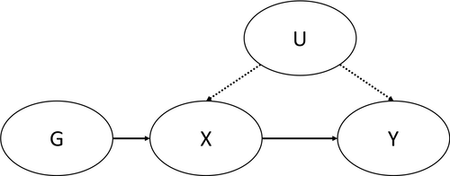

- G: genetic variant (instrument variable)
- Y: outcome variable
- X: exposure variable
- U: unknown confounders

# Assumptions

G: genetic variant; Y: outcome variable; X: exposure variable; U: unknown confounders

1. Independence between $G$ and $U$
   $$G \perp U$$
2. Established association between $G$ and $X$
   $$P(X|G) \ne P(X)$$
3. No alternative pathway from $G$ to $Y$, (exclusion restriction)
   $$G \perp Y | X, U$$

# Relaxed Assumptions

G: genetic variant; Y: outcome variable; X: exposure variable; U: unknown confounders; W: known confounders;

1. Independence between $G$ and $U$
   $$G \perp U | W$$
2. Established association between $G$ and $X$
   $$P(X|G, W) \ne P(X|W)$$
3. No alternative pathway from $G$ to $Y$, (exclusion restriction)
   $$G \perp Y | X, U, W$$

# Instrumental variable regression

- One sample MR
  - 2 Stage least square (2SLS)
    $$\boldsymbol{\beta}_{IV} =
    \{
    (\boldsymbol{X}^\top \boldsymbol{G})
    (\boldsymbol{G}^\top \boldsymbol{G})^\top
    (\boldsymbol{G}^\top \boldsymbol{X})
    \}^{-1}
    (\boldsymbol{X}^\top \boldsymbol{G})
    (\boldsymbol{G}^\top \boldsymbol{G})^\top
    (\boldsymbol{G}^\top \boldsymbol{Y}) \\$$
    $$\boldsymbol{\beta}_{IV}
    =
    (\hat{\boldsymbol{X}}^\top \hat{\boldsymbol{X}} )^{-1}
    \hat{\boldsymbol{X}} ^\top \boldsymbol{Y},
    \hat{\boldsymbol{X}}
    =
    \boldsymbol{G} (\boldsymbol{G}^\top \boldsymbol{G})^{-1} \boldsymbol{G} \boldsymbol{X}$$
- Two sample MR
  - Wald estiamtor
    $$\hat{\beta}_{IV} = \frac{\hat{\theta}_1}{\hat{\alpha}_1},$$
    where $\theta_1$ is the slope of regressing $Y$ on $G$, $\alpha_1$ is the slope of regressing $X$ on $G$.

# 2 Stage Least Square

$$\hat{\boldsymbol{X}}
=
\boldsymbol{G} (\boldsymbol{G}^\top \boldsymbol{G})^{-1} \boldsymbol{G} \boldsymbol{X}$$

$$\boldsymbol{\beta}_{IV}
=
(\hat{\boldsymbol{X}}^\top \hat{\boldsymbol{X}} )^{-1}
\hat{\boldsymbol{X}} ^\top \boldsymbol{Y}$$

- This is available in ivreg function in R package AER

```r
library(AER)
# ?ivreg
```

# Example data: CigarettesSW

- cpi: Consumer price index.
- packs: Number of packs per capita (per person).
- income: State personal income (total, nominal).
- price: Average price during fiscal year.
- tax: Average state, federal and average local excise taxes for fiscal year.
- taxs: Average excise taxes for fiscal year (sales tax).

```r
data("CigarettesSW")
head(CigarettesSW)
```

```
##   state year   cpi population    packs    income  tax     price     taxs
## 1    AL 1985 1.076    3973000 116.4863  46014968 32.5 102.18167 33.34834
## 2    AR 1985 1.076    2327000 128.5346  26210736 37.0 101.47500 37.00000
## 3    AZ 1985 1.076    3184000 104.5226  43956936 31.0 108.57875 36.17042
## 4    CA 1985 1.076   26444000 100.3630 447102816 26.0 107.83734 32.10400
## 5    CO 1985 1.076    3209000 112.9635  49466672 31.0  94.26666 31.00000
## 6    CT 1985 1.076    3201000 109.2784  60063368 42.0 128.02499 51.48333
```

# CigarettesSW

- intermediate variables

```r
CigarettesSW$rprice <- with(CigarettesSW, price/cpi)
CigarettesSW$rincome <- with(CigarettesSW, income/population/cpi)
CigarettesSW$tdiff <- with(CigarettesSW, (taxs - tax)/cpi)
CigarettesSW$ratio_tc <- with(CigarettesSW, tax/cpi)
```

- instrument variable: tdiff, ratio_tc
- exposure variable: rprice
- outcome variable: packs
- known confounding variable: rincome

Goal: examine whether higher cigarette price (price) could reduce smoking (pack)

# Valid instrument

Assumptoin 2: Established association between $G$ and $X$
$$P(X|G, W) \ne P(X|W)$$

- Verify the instrumental variable is associated with the exposure variable

```r
alm <- lm(log(rprice) ~ tdiff + log(rincome), data = CigarettesSW)
## alm <- lm(log(rprice) ~ ratio_tc + log(rincome), data = CigarettesSW)
summary(alm)
```

```
##
## Call:
## lm(formula = log(rprice) ~ tdiff + log(rincome), data = CigarettesSW)
##
## Residuals:
##       Min        1Q    Median        3Q       Max
## -0.219336 -0.056866  0.001329  0.062840  0.245333
##
## Coefficients:
##              Estimate Std. Error t value Pr(>|t|)
## (Intercept)  3.384429   0.157936  21.429  < 2e-16 ***
## tdiff        0.031206   0.003187   9.790 5.68e-16 ***
## log(rincome) 0.443583   0.061291   7.237 1.28e-10 ***
## ---
## Signif. codes:  0 '***' 0.001 '**' 0.01 '*' 0.05 '.' 0.1 ' ' 1
##
## Residual standard error: 0.08865 on 93 degrees of freedom
## Multiple R-squared:  0.6733, Adjusted R-squared:  0.6662
## F-statistic: 95.82 on 2 and 93 DF,  p-value: < 2.2e-16
```

# 2SLS Model fitting

```r
ivreg(y ~ x + w | w + g)
```

- y: outcome variable
- x: exposure variable
- g: instrumental variable
- w: known confounding variable

$$\hat{\boldsymbol{X}}
=
\boldsymbol{G} (\boldsymbol{G}^\top \boldsymbol{G})^{-1} \boldsymbol{G} \boldsymbol{X}$$

$$\boldsymbol{\beta}_{IV}
=
(\hat{\boldsymbol{X}}^\top \hat{\boldsymbol{X}} )^{-1}
\hat{\boldsymbol{X}} ^\top \boldsymbol{Y}$$

# 2SLS Model fitting

```r
fm <- ivreg(log(packs) ~ log(rprice) + log(rincome) | log(rincome) + tdiff + ratio_tc,
  data = CigarettesSW)
summary(fm)
```

```
##
## Call:
## ivreg(formula = log(packs) ~ log(rprice) + log(rincome) | log(rincome) +
##     tdiff + ratio_tc, data = CigarettesSW)
##
## Residuals:
##      Min       1Q   Median       3Q      Max
## -0.61378 -0.07232  0.01435  0.09486  0.37504
##
## Coefficients:
##              Estimate Std. Error t value Pr(>|t|)
## (Intercept)    9.7365     0.5687  17.122  < 2e-16 ***
## log(rprice)   -1.2291     0.1552  -7.922 4.94e-12 ***
## log(rincome)   0.2568     0.1434   1.791   0.0765 .
## ---
## Signif. codes:  0 '***' 0.001 '**' 0.01 '*' 0.05 '.' 0.1 ' ' 1
##
## Residual standard error: 0.1654 on 93 degrees of freedom
## Multiple R-Squared: 0.5486,  Adjusted R-squared: 0.5389
## Wald test: 39.93 on 2 and 93 DF,  p-value: 3.025e-13
```

# 2SLS Model diagnostic

```r
summary(fm, vcov = sandwich, df = Inf, diagnostics = TRUE)
```

```
##
## Call:
## ivreg(formula = log(packs) ~ log(rprice) + log(rincome) | log(rincome) +
##     tdiff + ratio_tc, data = CigarettesSW)
##
## Residuals:
##      Min       1Q   Median       3Q      Max
## -0.61378 -0.07232  0.01435  0.09486  0.37504
##
## Coefficients:
##              Estimate Std. Error z value Pr(>|z|)
## (Intercept)    9.7365     0.5060  19.243  < 2e-16 ***
## log(rprice)   -1.2291     0.1522  -8.078 6.59e-16 ***
## log(rincome)   0.2568     0.1503   1.709   0.0874 .
##
## Diagnostic tests:
##                  df1 df2 statistic p-value
## Weak instruments   2  92   145.502  <2e-16 ***
## Wu-Hausman         1  92     2.204   0.141
## Sargan             1  NA     0.018   0.893
## ---
## Signif. codes:  0 '***' 0.001 '**' 0.01 '*' 0.05 '.' 0.1 ' ' 1
##
## Residual standard error: 0.1654 on Inf degrees of freedom
## Multiple R-Squared: 0.5486,  Adjusted R-squared: 0.5389
## Wald test: 101.5 on 2 DF,  p-value: < 2.2e-16
```

# 2SLS Model diagnostic

- F statistics > 10, indicating strong instrument
- Wu-Hausman p > 0.05, indicating equivalence between $\beta_{OLS}$ and $\beta_{IV}$
- Sargan p > 0.05, indicating no pleiotropy.

# Two sample MR

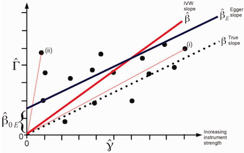

(Bowden et al. 2015), each dot represents the effects from one instrumental variable

- Wald method: individual instrument $\hat{\beta}_{IV} = \frac{\hat{\theta}_1}{\hat{\alpha}_1}$
- Inverse-variance weighted regression (IVW): intercept is zero.
  - The causal effect is the regression slope.
- Egger regression: intercept can be non-zero.
  - The causal effect is the regression slope.
  - If the intercept is non-zero, there is a pleiotropy effect

# Two sample MR

- Load the R package

```r
library(TwoSampleMR)
```

Goal: investigate whether higher BMI (exposure) causes Coronary heart disease (outcome)

# Datasets

- Many datasets are available within the R package
- Or you can prepare your own data

```r
ao <- available_outcomes()
```

```
## API: public: http://gwas-api.mrcieu.ac.uk/
```

```r
head(subset(ao, select=c(trait, id)))
```

```
## # A tibble: 6 x 2
##   trait                                                 id
##   <chr>                                                 <chr>
## 1 ENSG00000134884                                       eqtl-a-ENSG0000013…
## 2 Operative procedures - main OPCS: B27.4 Total mastec… ukb-b-20278
## 3 ENSG00000170464                                       eqtl-a-ENSG0000017…
## 4 ENSG00000090263                                       eqtl-a-ENSG0000009…
## 5 Lamina-associated polypeptide 2, isoforms beta/gamma  prot-a-3021
## 6 ENSG00000251637                                       eqtl-a-ENSG0000025…
```

# Get instruments and exposure variable (BMI)

```r
bmi_exp_dat0 <- extract_instruments("ieu-a-2")
head(bmi_exp_dat0)
```

```
##   pval.exposure samplesize.exposure chr.exposure se.exposure beta.exposure
## 1   2.18198e-08              339152            1      0.0030       -0.0168
## 2   4.56773e-11              339065            1      0.0031        0.0201
## 3   5.05941e-14              313621            1      0.0087        0.0659
## 4   1.93299e-08              294030            3      0.0033        0.0183
## 5   2.53501e-10              337750            6      0.0033        0.0209
## 6   4.52376e-31              339197            6      0.0038        0.0444
##   pos.exposure id.exposure        SNP effect_allele.exposure
## 1     47684677     ieu-a-2   rs977747                      G
## 2     78048331     ieu-a-2 rs17381664                      C
## 3    110082886     ieu-a-2  rs7550711                      T
## 4     81792112     ieu-a-2  rs3849570                      A
## 5     34828553     ieu-a-2  rs6457796                      C
## 6     50865820     ieu-a-2   rs943005                      T
##   other_allele.exposure eaf.exposure                      exposure
## 1                     T       0.5333 Body mass index || id:ieu-a-2
## 2                     T       0.4250 Body mass index || id:ieu-a-2
## 3                     C       0.0339 Body mass index || id:ieu-a-2
## 4                     C       0.3667 Body mass index || id:ieu-a-2
## 5                     T       0.2583 Body mass index || id:ieu-a-2
## 6                     C       0.1000 Body mass index || id:ieu-a-2
##   mr_keep.exposure pval_origin.exposure data_source.exposure
## 1             TRUE             reported                  igd
## 2             TRUE             reported                  igd
## 3             TRUE             reported                  igd
## 4             TRUE             reported                  igd
## 5             TRUE             reported                  igd
## 6             TRUE             reported                  igd
```

```r
dim(bmi_exp_dat0)
```

```
## [1] 79 15
```

# Exposure data explanation

- this defines the regression coefficient of $X$ on $G$.

The minimum information required for MR analysis is the following:

- SNP: rs ID (instrumental variable)
- beta: The effect size. If the trait is binary then log(OR) should - be used
- se: The standard error of the effect size
- effect_allele: The allele of the SNP which has the effect marked in beta

# Data clumping

- For one sample/two sample MR
  - It is important to ensure that the instruments for the exposure are independent.
  - Otherwise, there is a colinearility issue.
  - The correlation is calculated by Linkage disequilibrium (LD), which has been esitmated from the 1000 genomes project

```r
bmi_exp_dat <- clump_data(bmi_exp_dat0)
```

```
## Clumping ieu-a-2, 79 variants
```

```
## Removing 1 of 79 variants due to LD with other variants or absence from LD reference panel
```

```r
dim(bmi_exp_dat)
```

```
## [1] 78 15
```

# Outcome data

- this defines the regression coefficient of $Y$ on $G$.
- We only focus on those SNPs (instrumental variabls) identified in the previous step.

```r
chd_out_dat <- extract_outcome_data(snps=bmi_exp_dat$SNP, outcomes="ieu-a-7")
```

```
## Extracting data for 78 SNP(s) from 1 GWAS(s)
```

```r
head(chd_out_dat)
```

```
##          SNP chr       pos beta.outcome se.outcome samplesize.outcome
## 1   rs977747   1  47684677    -0.013896  0.0096146             184305
## 2 rs17203016   2 208255518     0.020352  0.0122315             184305
## 3  rs7550711   1 110082886    -0.048354  0.0305635             184305
## 4  rs9374842   6 120185665     0.013555  0.0106053             184305
## 5  rs4740619   9  15634326    -0.006546  0.0092497             184305
## 6  rs2112347   5  75015242    -0.005855  0.0096581             184305
##   pval.outcome eaf.outcome effect_allele.outcome other_allele.outcome
## 1    0.1483750    0.550761                     G                    T
## 2    0.0961324    0.186737                     G                    A
## 3    0.1136310    0.027650                     T                    C
## 4    0.2012030    0.723965                     T                    C
## 5    0.4791310    0.467784                     C                    T
## 6    0.5443640    0.401399                     G                    T
##                                outcome id.outcome   originalname.outcome
## 1 Coronary heart disease || id:ieu-a-7    ieu-a-7 Coronary heart disease
## 2 Coronary heart disease || id:ieu-a-7    ieu-a-7 Coronary heart disease
## 3 Coronary heart disease || id:ieu-a-7    ieu-a-7 Coronary heart disease
## 4 Coronary heart disease || id:ieu-a-7    ieu-a-7 Coronary heart disease
## 5 Coronary heart disease || id:ieu-a-7    ieu-a-7 Coronary heart disease
## 6 Coronary heart disease || id:ieu-a-7    ieu-a-7 Coronary heart disease
##               outcome.deprecated mr_keep.outcome data_source.outcome
## 1 Coronary heart disease ||  ||             TRUE                 igd
## 2 Coronary heart disease ||  ||             TRUE                 igd
## 3 Coronary heart disease ||  ||             TRUE                 igd
## 4 Coronary heart disease ||  ||             TRUE                 igd
## 5 Coronary heart disease ||  ||             TRUE                 igd
## 6 Coronary heart disease ||  ||             TRUE                 igd
```

# Harmonise data

This means that the effect of a SNP on the exposure and the effect of that SNP on the outcome must each correspond to the same allele.

```r
dat <- harmonise_data(
    exposure_dat = bmi_exp_dat,
    outcome_dat = chd_out_dat
)
```

```
## Harmonising Body mass index || id:ieu-a-2 (ieu-a-2) and Coronary heart disease || id:ieu-a-7 (ieu-a-7)
```

```r
head(dat)
```

```
##          SNP effect_allele.exposure other_allele.exposure
## 1  rs1000940                      G                     A
## 2 rs10132280                      A                     C
## 3  rs1016287                      C                     T
## 4 rs10182181                      G                     A
## 5 rs10733682                      G                     A
## 6 rs10840100                      G                     A
##   effect_allele.outcome other_allele.outcome beta.exposure beta.outcome
## 1                     G                    A        0.0184    -0.014538
## 2                     A                    C       -0.0221    -0.012169
## 3                     C                    T       -0.0228    -0.014087
## 4                     G                    A        0.0309     0.018295
## 5                     G                    A       -0.0188    -0.004541
## 6                     G                    A        0.0206     0.014599
##   eaf.exposure eaf.outcome remove palindromic ambiguous id.outcome chr
```

[output cut: 48 more lines]

# Perform MR

- Wald method

```r
res_single <- mr_singlesnp(dat)
```

- IVW and Egger regression

```r
res <- mr(dat, method_list=c("mr_egger_regression", "mr_ivw"))
```

```
## Analysing 'ieu-a-2' on 'ieu-a-7'
```

```r
res
```

```
##   id.exposure id.outcome                              outcome
## 1     ieu-a-2    ieu-a-7 Coronary heart disease || id:ieu-a-7
## 2     ieu-a-2    ieu-a-7 Coronary heart disease || id:ieu-a-7
##                        exposure                    method nsnp         b
## 1 Body mass index || id:ieu-a-2                  MR Egger   78 0.4926008
## 2 Body mass index || id:ieu-a-2 Inverse variance weighted   78 0.4505027
##           se         pval
## 1 0.14436715 1.035793e-03
## 2 0.05913769 2.579139e-14
```

# References

- https://mrcieu.github.io/TwoSampleMR/articles/introduction.html
- https://cran.r-project.org/web/packages/AER/AER.pdf